# Seattle incidents: Vehicle theft and bicycle theft compared

Gerard Meester

March 19, 2016

```
## [1] "C"
```

# Purpose comparative analysis

It is interesting to compare bike theft and theft of other vehicles in Seattle. Because both pertain to theft of vehicles, and could possibly be very similar. This would for example be the cases if the same gangs are responsible for both bike theft and car theft.

So the purpose of this analysis is to investigate if bike theft and vehicle theft are similar or different in term of daytime pattern, weekly pattern and distribution over geographical distribution over the city.

# Comparision of time distribution of bike theft and vehicle theft

I start to compare the distribution of bike theft and vehicle over the different hours of the day.

The figures below show that the distribution over the hours of the day are diffent: the theft of other vehicles has a sharp peak in the early night (starting from 20:00 till 1:00) while bike theft is more common in the afternoon and the early evening.

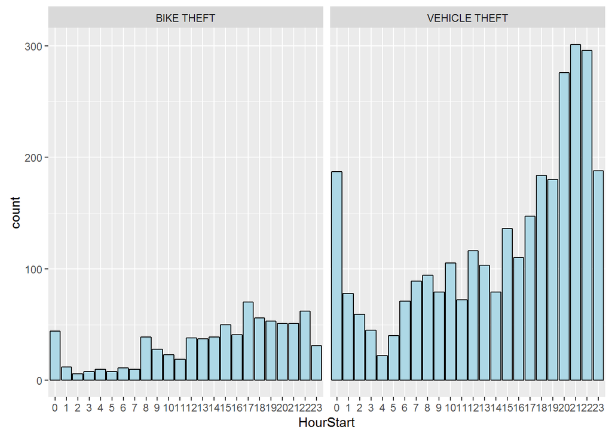

It is interesting to investigate if the distribution over the different days of the week is similar for bike theft and theft of other vehicles.

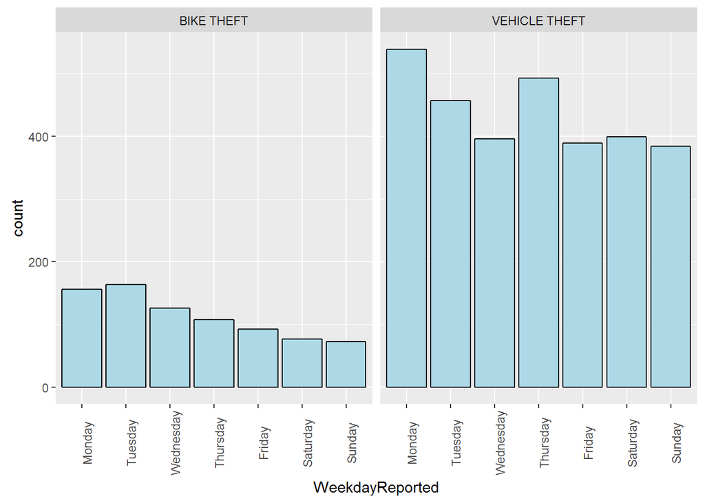

The barcharts show that the distributions are different, although both bike theft and vehicle theft have relative counts on Saturday and Sunday, vehicle theft has peaks on Monday and Thursday, while bike theft is at its highest on Tuesday.

# Comparison of geographical distribution bike theft and vehicle theft

Looking at the geographical distribution of these to types of theft, the picture of Bike theft (left map) and Vehicle theft (right map) is the following:

[figure not shown]

When we plot the locations of the two differet types of theft using a contour map, the picture becomes more clear:

[figure not shown]

The contour maps show that Bike theft is a phenonemon which occurs most in the centre of Seattle. Other vehicles are stolen all over Seattle. The geographical distributions are clearly very different.

# Overall Conclusion